# PersonalityPlus Evaluation

Srihari Mohan

June 9, 2016

[output not shown]

[output not shown]

[output not shown]

[output not shown]

[output not shown]

[output not shown]

[output not shown]

[output not shown]

[output not shown]

[output not shown]

[output not shown]

[output not shown]

Initialize the data workspace using Tony Tarasco’s updated CSV.

```r
teamData <- read.csv("teamchem.csv",header=T,sep=",",quote="\"",dec=".",fill=T,
                     comment.char = "", stringsAsFactors = F)
teamData$ExpWins <- c(94,87,76,95,88,76,85,82,82) #TODO: account for injury offset
teamData$Wins <- round(c(104,.597*162,66,88,98,75,86,96,83),2)
teamData$Boost <- round(teamData$Wins - teamData$ExpWins,2)
names(teamData)[27] <- "Boost"
teamData$PersonalityPlus <- ifelse(teamData$Boost > 0, gsub(" ","",paste("+",as.integer(teamData$Boost)),fixed=T),
                                   gsub(" ","",paste("-",-1*as.integer(teamData$Boost)),fixed=T))
write.csv(teamData,"PersonalityPlus.csv",row.names=F)
```

Here I set up the training subset to test both the ML models and my custom cosine similarity metric.

```r
nSize <- nrow(teamData)
train <- sample(seq(nSize),as.integer(0.75 * nSize),replace=F)
```

inTrain is the training subset I use to test the Boosting Model and Logistic Regression on.

```r
inTrain <- modified[train,]
rownames(inTrain) <- inTrain$Tm
inTrain <- within(inTrain,rm("Tm","Boost"))
```

In the case of significant correlations between frequency counts in the vectors, I used Principal Components Analysis (PCA), a form of dimensionality reduction, to take successive linear combinations of the personality vectors with maximum variance. Each principal component is uncorrelated with the previous, such that the majority of the variance in the data can be explained by these M principal components rather than our original p predictor variables (where M < p). The PCA analysis should lead to a less variable model that doesn’t overfit to the training data.

```r
prComp <- prcomp(inTrain,scale=T)
summary(prComp)
```

```
## Importance of components:
##                           PC1    PC2    PC3    PC4     PC5       PC6
## Standard deviation     2.6442 2.5132 1.8869 1.6039 1.24867 4.301e-16
## Proportion of Variance 0.3329 0.3008 0.1695 0.1225 0.07425 0.000e+00
## Cumulative Proportion  0.3329 0.6337 0.8033 0.9257 1.00000 1.000e+00
```

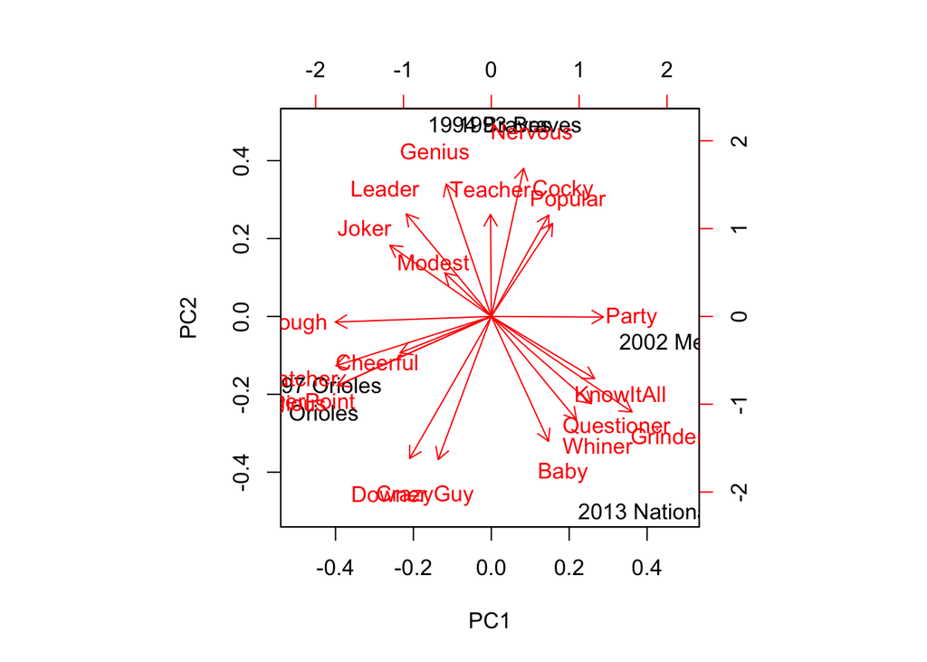

```r
cor(inTrain) #gives variable correlations
```

```
##                 Grinder       Joker       Pious       Party       Tough
## Grinder      1.00000000 -0.66677198 -0.48926145  0.57950938 -0.66677198
## Joker       -0.66677198  1.00000000  0.35082321 -0.42443949  0.72307692
## Pious       -0.48926145  0.35082321  1.00000000 -0.43994135  0.87705802
## Party        0.57950938 -0.42443949 -0.43994135  1.00000000 -0.42443949
## Tough       -0.66677198  0.72307692  0.87705802 -0.42443949  1.00000000
## Leader      -0.82613906  0.39186207  0.09712859 -0.64096321  0.18741229
## Nervous     -0.37435720  0.33091126 -0.60024505 -0.15089864 -0.30082842
## FingerPoint -0.48926145  0.35082321  1.00000000 -0.43994135  0.87705802
## Modest      -0.36984690 -0.33149677  0.18898224 -0.08314110  0.06629935
## CrazyGuy     0.18778775 -0.02303267  0.52522573 -0.51990416  0.25335939
## Popular      0.10453110  0.24359938 -0.46291005  0.33942212 -0.08119979
## Downer       0.05322463 -0.12403473  0.70710678 -0.51847585  0.37210420
## Cheerful    -0.30943611 -0.27735010  0.63245553 -0.13912167  0.38829014
## Baby         0.69192018 -0.12403473  0.00000000  0.31108551 -0.12403473
## Genius      -0.55312658  0.64450339  0.00000000  0.00000000  0.42966892
## Teacher     -0.45225278  0.05547002 -0.31622777 -0.13912167 -0.27735010
## Cocky       -0.04760556  0.11094004 -0.63245553 -0.27824334 -0.38829014
## KnowItAll    0.74967661 -0.67194123 -0.25537696  0.86135677 -0.40316474
## Watcher     -0.58335020  0.57008771  0.87500000 -0.76989735  0.83320512
## Questioner   0.71196867 -0.50161031 -0.43994135 -0.09677419 -0.65595194
## Whiner       0.69028056 -0.61017022 -0.31622777 -0.13912167 -0.61017022
##                  Leader     Nervous FingerPoint      Modest    CrazyGuy
## Grinder     -0.82613906 -0.37435720 -0.48926145 -0.36984690  0.18778775
## Joker        0.39186207  0.33091126  0.35082321 -0.33149677 -0.02303267
## Pious        0.09712859 -0.60024505  1.00000000  0.18898224  0.52522573
## Party       -0.64096321 -0.15089864 -0.43994135 -0.08314110 -0.51990416
## Tough        0.18741229 -0.30082842  0.87705802  0.06629935  0.25335939
## Leader       1.00000000  0.66629660  0.09712859  0.29368924 -0.17855051
## Nervous      0.66629660  1.00000000 -0.60024505 -0.06482037 -0.58549055
## FingerPoint  0.09712859 -0.60024505  1.00000000  0.18898224  0.52522573
## Modest       0.29368924 -0.06482037  0.18898224  1.00000000 -0.34740417
## CrazyGuy    -0.17855051 -0.58549055  0.52522573 -0.34740417  1.00000000
## Popular     -0.26977079  0.31755367 -0.46291005  0.00000000 -0.60783067
## Downer      -0.13736056 -0.72760688  0.70710678  0.00000000  0.92847669
## Cheerful     0.06142951 -0.54232614  0.63245553  0.83666003  0.08304548
## Baby        -0.68680282 -0.48507125  0.00000000 -0.80178373  0.55708601
## Genius       0.23791548  0.42008403  0.00000000  0.23145502 -0.64326752
## Teacher      0.79858365  0.75925660 -0.31622777  0.11952286 -0.41522740
## Cocky        0.30714756  0.70502399 -0.63245553  0.05976143 -0.33218192
```

[output cut: 55 more lines]

```
## Nervous     -0.2169305
## FingerPoint -0.3162278
## Modest      -0.2390457
## CrazyGuy     0.5813184
## Popular     -0.2927700
## Downer       0.4472136
## Cheerful    -0.2000000
## Baby         0.4472136
## Genius      -0.7745967
## Teacher     -0.2000000
## Cocky        0.2000000
## KnowItAll    0.1615146
## Watcher     -0.1581139
## Questioner   0.9738517
## Whiner       1.0000000
```

Below is a modified version of my Cosine Similarity metric. I will continue to use it until we get a large enough training set to move to the more refined statistial learning tools described above.

To reiterate on the logic, a vector is constructed from the counts of each player type and then fed into the method below that measures the similarity between two vectors through their cosine similarities. The training data is aggregated into personality clusters such that vectors with cosine similarities above a conventional threshold are grouped together. A running average among the counts of each personality type per bucket is recorded and used as a reference in testing. Specifically, a test sample is bucketed into the personality cluster with which it shares its highest cosine similarity with.

```r
# (Self-Created) Cosine Similarity Vector Clustering Method - good for smaller datasets
# similar vectors grouped together, dissimilar vectors clustered

acceptInput <- function() {
  textPrompt <- "Enter a Team Name: "
  input <- readline(prompt = textPrompt)
  input <- as.character(input)
  if(is.na(input)) {
    print("Not quite. Try again.")
    input <- acceptInput()
  }
  textPrompt <- "Input list of personality frequencies: "
  EXP <- as.integer(strsplit(readline(textPrompt), " ")[[1]])
  return (EXP)
}

simplify_cluster <- function(x) {
  x <- unique(x)
  return (x)
}

my_compare <- function(c,a) {
  cmp <- cosine(c,a)[[1]]
  return (cmp)
}

getSimilarityLists <- function(teamData) {
  teamLength <- nrow(teamData)
  my_list <- list()
  for(i in 1:(teamLength-1)) {
    for(j in (i+1):teamLength) {
      numerical1 <- teamData[i,][c(2:22)]
      numerical2 <- teamData[j,][c(2:22)]
      numerical1 <- as.numeric(numerical1)
      numerical2 <- as.numeric(numerical2)
      dist <- cosine(numerical1,numerical2)[[1]]
      if(dist >= 0.800) {
        if(length(my_list) == 0) {
          my_list[[1]] = c(i,j)
        } else {
          my_list[[length(my_list)+1]] <- c(i,j)
        }
      }
    }
  }
  return (my_list);
}

updateSimilarityList <- function(my_list) {
  teamLength <- length(my_list)
  teamLength
  for(i in 1:(teamLength-1)) {
    if(i < teamLength & teamLength-1 > 0) {
      for(j in (i+1):teamLength) {
        if(my_list[[i]][[1]] == my_list[[j]][[1]]
           | my_list[[i]][[1]] == my_list[[j]][[2]]
           | my_list[[i]][[2]] == my_list[[j]][[1]]
           | my_list[[i]][[2]] == my_list[[j]][[2]]) {
          if(length(my_list) == 0) {
            my_list[[1]] <- append(my_list[[i]],my_list[[j]])
          } else {
            my_list[[i]] <- append(my_list[[i]],my_list[[j]])
          }
        }
      }
    }
  }
  return (my_list);
}

getClusters <- function(my_list, teamData) {
  clusters <- list()
  teamLength <- length(my_list)
  for(i in 1:teamLength) {
    curr <- my_list[[i]]
    clusterMatrix <- teamData[curr,]
    clusterMatrix <- clusterMatrix[,c(2:22)]
    temp <- apply(clusterMatrix,2,mean)
    temp <- as.numeric(round(temp,3))
    clusters[[i]] <- temp
  }
  return (clusters);
}

# setup
teamCopy <- teamData
teamCopy <- within(teamCopy,rm("ExpWins","Wins","PersonalityPlus"))
nSize <- nrow(teamCopy)
train <- sample(seq(nSize),as.integer(0.75 * nSize),replace=F)
cosTrain <- teamCopy[train,]
cosTest <- teamCopy[-train,]
cosTrain <- within(cosTrain,rm("Bully","Paranoia"))
cosTest <- within(cosTest,rm("Bully","Paranoia"))
nTest <- nrow(cosTest)
```

Once bucketed, a separate neural network runs a regression with inputs equal to the counts of a test sample’s personality vector and the output equal to the expected team chemistry delta. The neural net is trained on the teams bucketed into each personality cluster in the training phase.

```r
# predict on test data
for(i in 1:nTest) {
  testinput <- as.numeric(cosTest[i,2:22])
  my_list <- getSimilarityLists(cosTrain)
  my_list <- updateSimilarityList(my_list)
  my_list <- lapply(my_list,simplify_cluster)
  clusters <- getClusters(my_list,cosTrain)

  # build required number of neural nets (1 per cluster)
  clusters <- unique(clusters)
  my_list <- lapply(my_list,sort)
  my_list <- unique(my_list)

  # determine cluster for input
  bins <- sapply(clusters,my_compare,a=testinput)
  teambin <- which.max(bins)
  df1 <- cosTrain[my_list[[teambin]],]
  nnChem <- neuralnet(Boost ~ Grinder + Joker + Pious + Party + Tough + Leader + Nervous
                      + FingerPoint + Modest    + CrazyGuy + Popular + Downer   + Cheerful
                      + Baby + Genius + Teacher + Cocky + KnowItAll + Watcher + Questioner
                      + Whiner, data = df1, hidden=3, err.fct="sse", algorithm="rprop+",
                      act.fct="logistic", linear.output=T, learningrate=.1)
  testnetChem <- compute(nnChem,covariate=matrix(testinput,byrow=T,ncol = 21))
  delta <- round(testnetChem$net.result[[1]],2)
  print(paste("Expected Team Chemistry Boost:",delta))
}
```

```
## [1] "Expected Team Chemistry Boost: 13.99"
## [1] "Expected Team Chemistry Boost: 1.54"
## [1] "Expected Team Chemistry Boost: -4.27"
```